# Movie Success Prediction

The top first actor/actress has the most number of facebook popularity, while the second and the third actor/actress have much lower popularity. But it can also be shown that, high facebook popularity of the leading actor/actress does not mean that a movie is of high rating.

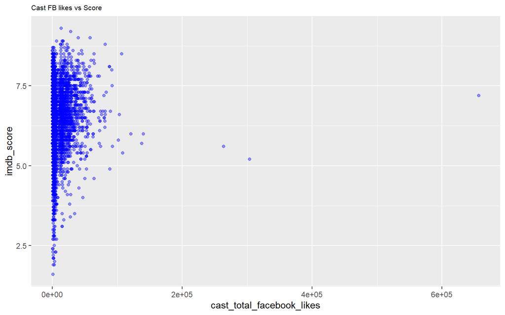

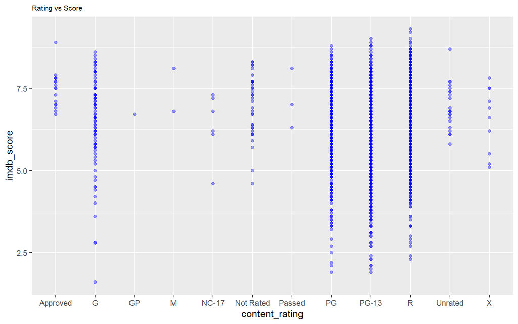

**Who got more FB likes?**

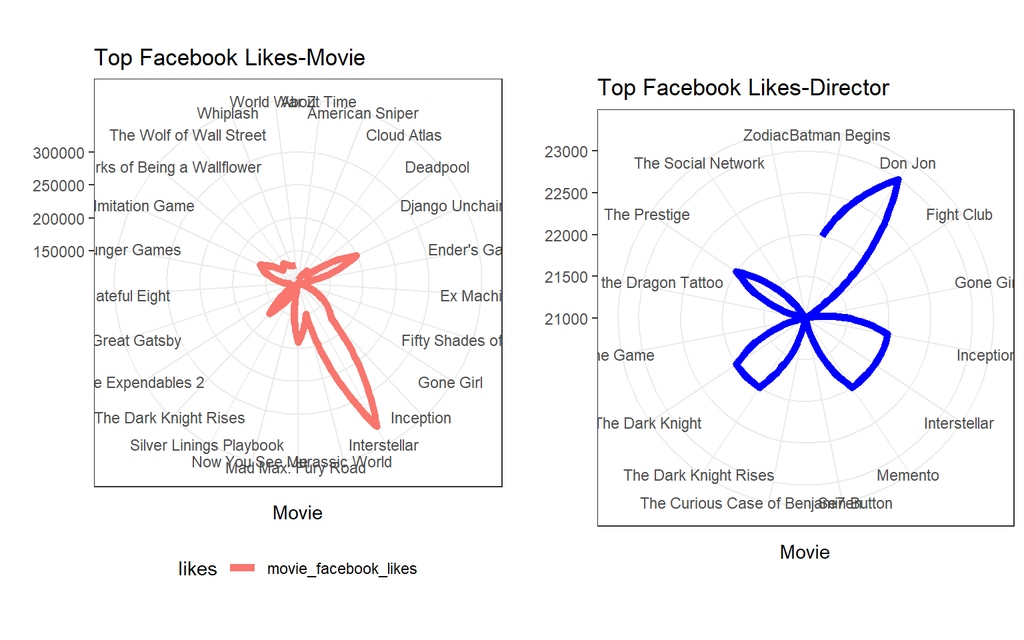

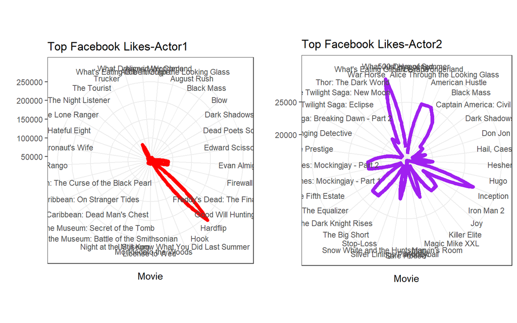

# Principal Component Analysis

```
   num_critic_for_reviews                  duration   director_facebook_likes
                 1.67e+02                  1.10e+02                  8.07e+02
   actor_3_facebook_likes    actor_1_facebook_likes                     gross
                 7.71e+02                  7.75e+03                  5.26e+07
          num_voted_users cast_total_facebook_likes      facenumber_in_poster
                 1.06e+05                  1.15e+04                  1.38e+00
     num_user_for_reviews                    budget                title_year
                 3.37e+02                  4.62e+07                  2.00e+03
   actor_2_facebook_likes                imdb_score              aspect_ratio
                 2.02e+03                  6.47e+00                  2.11e+00
     movie_facebook_likes
                 9.35e+03
```

```
   num_critic_for_reviews                  duration   director_facebook_likes
                 1.52e+04                  5.13e+02                  9.41e+06
   actor_3_facebook_likes    actor_1_facebook_likes                     gross
                 3.59e+06                  2.41e+08                  4.94e+15
          num_voted_users cast_total_facebook_likes      facenumber_in_poster
                 2.31e+10                  3.66e+08                  4.17e+00
     num_user_for_reviews                    budget                title_year
                 1.69e+05                  5.11e+16                  9.78e+01
   actor_2_facebook_likes                imdb_score              aspect_ratio
                 2.07e+07                  1.12e+00                  1.25e-01
     movie_facebook_likes
                 4.61e+08
```

```
                          num_critic_for_reviews duration
num_critic_for_reviews                    1.0000   0.2286
duration                                  0.2286   1.0000
director_facebook_likes                   0.1751   0.1806
actor_3_facebook_likes                    0.2528   0.1258
                          director_facebook_likes actor_3_facebook_likes
num_critic_for_reviews                     0.1751                 0.2528
duration                                   0.1806                 0.1258
director_facebook_likes                    1.0000                 0.1174
actor_3_facebook_likes                     0.1174                 1.0000
                          actor_1_facebook_likes   gross num_voted_users
num_critic_for_reviews                    0.1660  0.4642          0.5925
duration                                  0.0836  0.2457          0.3396
director_facebook_likes                   0.0896  0.1384          0.2996
actor_3_facebook_likes                    0.2524  0.2999          0.2678
                          cast_total_facebook_likes facenumber_in_poster
num_critic_for_reviews                       0.2365              -0.0344
duration                                     0.1202               0.0269
director_facebook_likes                      0.1185              -0.0481
actor_3_facebook_likes                       0.4898               0.1062
                          num_user_for_reviews  budget title_year
num_critic_for_reviews                  0.5637  0.1047     0.4202
duration                                0.3516  0.0680    -0.1302
director_facebook_likes                 0.2171  0.0182    -0.0447
actor_3_facebook_likes                  0.2053  0.0400     0.1175
                          actor_2_facebook_likes imdb_score aspect_ratio
num_critic_for_reviews                    0.2531     0.3479       0.1802
duration                                  0.1289     0.3662       0.1530
director_facebook_likes                   0.1161     0.1923       0.0375
actor_3_facebook_likes                    0.5538     0.0655       0.0464
                          movie_facebook_likes
num_critic_for_reviews                  0.7052
duration                                0.2153
director_facebook_likes                 0.1620
actor_3_facebook_likes                  0.2715
 [ reached getOption("max.print") -- omitted 12 rows ]
```

```
Importance of components:
                         PC1   PC2   PC3    PC4    PC5    PC6    PC7    PC8
Standard deviation     2.106 1.464 1.226 1.0250 1.0068 0.9981 0.9400 0.9307
Proportion of Variance 0.277 0.134 0.094 0.0657 0.0634 0.0623 0.0552 0.0541
Cumulative Proportion  0.277 0.411 0.505 0.5709 0.6342 0.6965 0.7517 0.8059
                          PC9   PC10  PC11   PC12  PC13   PC14    PC15    PC16
Standard deviation     0.8829 0.7704 0.693 0.6660 0.645 0.4927 0.38655 0.04209
Proportion of Variance 0.0487 0.0371 0.030 0.0277 0.026 0.0152 0.00934 0.00011
Cumulative Proportion  0.8546 0.8917 0.922 0.9494 0.975 0.9906 0.99989 1.00000
```

```
                               PC1      PC2     PC3     PC4     PC5      PC6
num_critic_for_reviews    -0.36244  0.15419 -0.3309  0.0592 -0.0440  0.08365
duration                  -0.20752  0.17773  0.2725 -0.4743  0.0605 -0.15681
director_facebook_likes   -0.15773  0.09445  0.2088 -0.1278 -0.1182  0.15828
actor_3_facebook_likes    -0.25171 -0.27809  0.0079  0.1366  0.2930 -0.13684
                              PC7     PC8      PC9    PC10     PC11     PC12
num_critic_for_reviews    -0.0457  0.1649  0.07969 -0.0273  0.01592 -0.10690
duration                  -0.0907 -0.0594  0.25175 -0.7082 -0.09019  0.07594
director_facebook_likes    0.8491  0.2289 -0.27761 -0.0337 -0.00449  0.09582
actor_3_facebook_likes     0.2860 -0.3235  0.33366  0.0774  0.06650  0.01008
                              PC13     PC14     PC15      PC16
num_critic_for_reviews    -0.04123 -0.74517 -0.34336  1.77e-03
duration                   0.00606  0.02704 -0.08046 -1.77e-03
director_facebook_likes   -0.02738 -0.05025  0.05665  8.38e-06
actor_3_facebook_likes     0.64244 -0.04913 -0.00745 -1.12e-01
 [ reached getOption("max.print") -- omitted 12 rows ]
```

## Plots

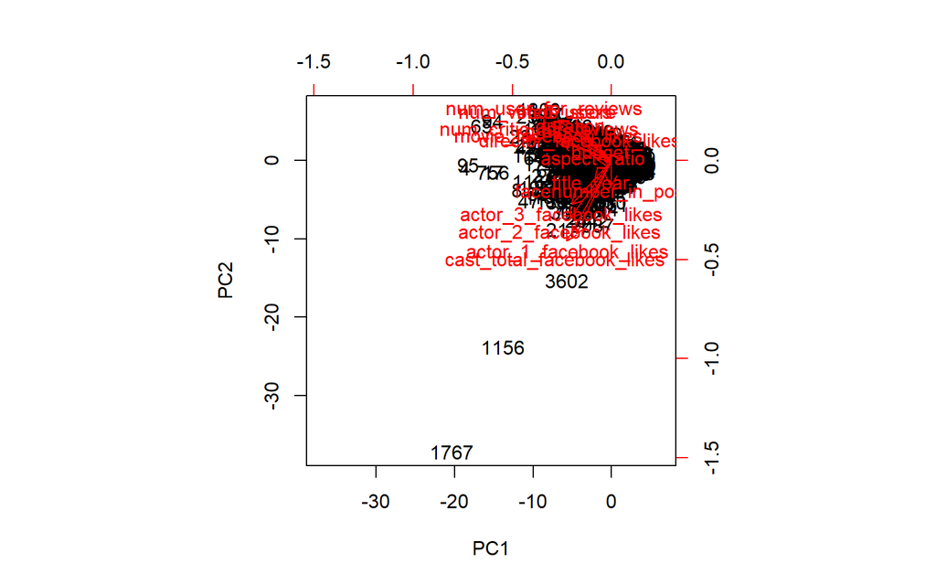

**Let us plot the cumulation of variance using the sd**

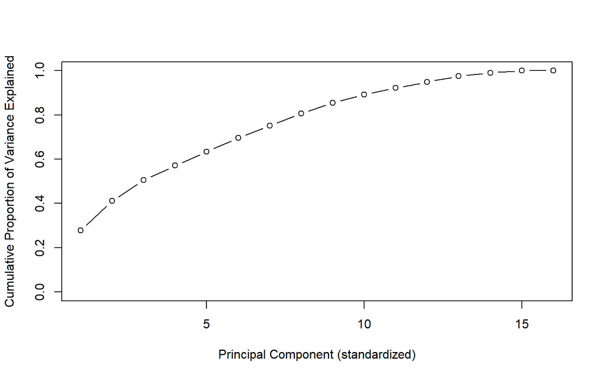

## Princiapl Component Regression

```
   num_critic_for_reviews                  duration   director_facebook_likes
                  0.07051                   0.03776                   0.02981
   actor_3_facebook_likes    actor_1_facebook_likes                     gross
                  0.05190                   0.04568                   0.06245
          num_voted_users cast_total_facebook_likes      facenumber_in_poster
                  0.07319                   0.05840                   0.00215
     num_user_for_reviews                    budget                title_year
                  0.06546                   0.01148                   0.02399
   actor_2_facebook_likes              aspect_ratio      movie_facebook_likes
                  0.05386                   0.01875                   0.06214
```

**Validations**

We can check and see where are mean square error prediction is the lowest

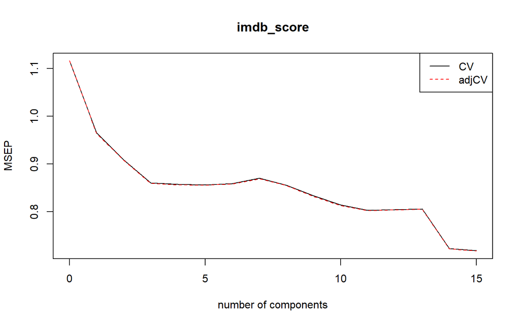

# Modeling

## Linear Regression

Linear regression, which is the most basic type of regression is used for predicting movie ratings. Linear regression can be used in studying relationship between two variables namely dependent and independent. In predicting movie ratings, we use imdb_score to be the dependent attribute and set the all numeric attributes to be independent variables. Csv file is read and set of all numeric attributes are extracted. Missing records are removed in order to minimize error and data is scaled as required. Different folds of training and test data sets are used. Model is created for linear regression using training data. Model created is applied to test data to obtain predictions. Root mean square error is estimated. Graph is plotted between actual and predicted data.

I have used generalized linear model (glm()) as the function that tells R to run a generalized linear model.Using RMSE makes a lot more sense when error term is distributed normally with mean zero.

A well-fitting regression model results in predicted values close to the observed data values. The mean model, which uses the mean for every predicted value, generally would be used if there were no informative predictor variables. The fit of a proposed regression model should therefore be better than the fit of the mean model. Three statistics are used in Ordinary Least Squares (OLS) regression to evaluate model fit: R-squared, the overall F-test, and the Root Mean Square Error (RMSE). All three are based on two sums of squares: Sum of Squares Total (SST) and Sum of Squares Error (SSE). SST measures how far the data are from the mean, and SSE measures how far the data are from the model’s predicted values. Different combinations of these two values provide different information about how the regression model compares to the mean model.

The RMSE is the square root of the variance of the residuals. It indicates the absolute fit of the model to the data–how close the observed data points are to the model’s predicted values. Whereas R-squared is a relative measure of fit, RMSE is an absolute measure of fit. As the square root of a variance, RMSE can be interpreted as the standard deviation of the unexplained variance, and has the useful property of being in the same units as the response variable. Lower values of RMSE indicate better fit. RMSE is a good measure of how accurately the model predicts the response, and it is the most important criterion for fit if the main purpose of the model is prediction.

```
[1] 0.00869
```

```
[1] 0.00799
```

```
[1] 0.00778
```

```
[1] 0.00777
```

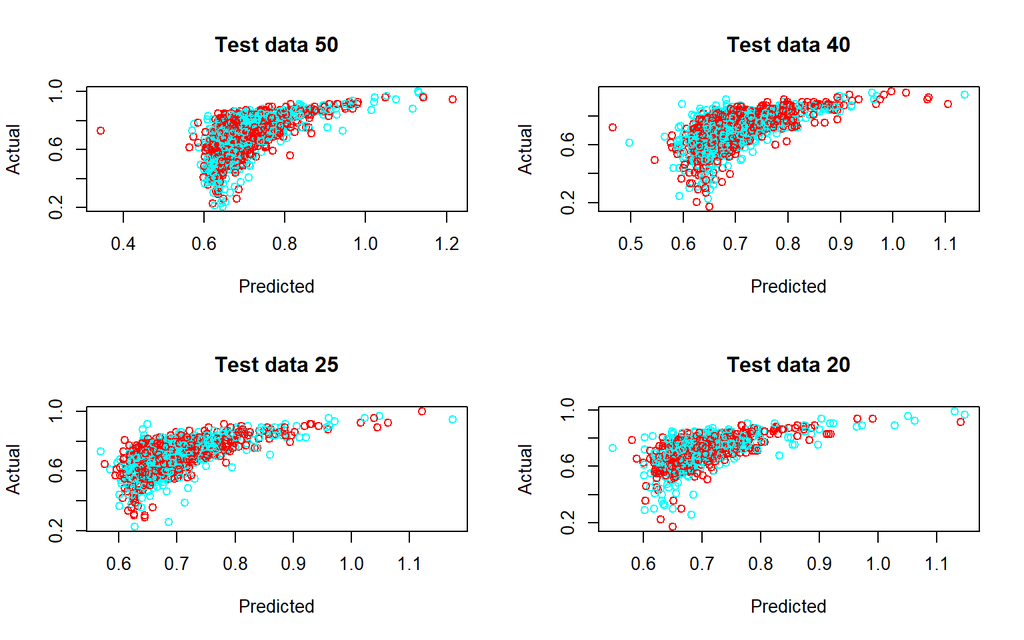